# 단순회귀모형(simple regression models)

## 회귀분석(regression analysis)

독립변수(independent variable, 설명변수:explanatory variable)들과 종속변수(dependent variable, 반응변수:response variable)간의 함수관계를 규명하는 통계적인 분석방법

## 단순회귀모형(simple regression models)

모형이 회귀계수로 볼 때도 선형(linear in the regression coefficient)이고, 독립변수(설명변수)로 볼 때도 선형(linear in the independent variable)이며, 독립변수가 하나뿐이므로 단순회귀모형이라고 한다.
$$Y_i=\beta_0 + \beta_1X_i +
\epsilon_i$$
$Y_i$는 상수항($\beta_0 + \beta_1X_i$)과 오차항($\epsilon_i$)으로 구성되어 있다.

1. $Y_i$는 i번째 측정된 Y값으로 확률변수이다.
2. 오차항의 평균 $E(\epsilon_i)=0$이므로,  
   $E(Y_i)=E(\beta_0+\beta_1X_i+\epsilon_i) = \beta_0+\beta_iXi + E(\epsilon_i) = \beta_0+\beta_1X_i$이다.  
   $\beta_0+\beta_1X_i$은 상수항이기 때문에 $E(\beta_0+\beta_1X_i)=\beta_0+\beta_1X_i$가 된다.  
   주어진 $X$에서 $Y$의 기대값을 $\mu_{Y.X}=\beta_0+\beta_1X$라고하면 $Y=\mu_{Y.X}+\epsilon$으로 표현한다.
3. 오차항$\epsilon_i$의 분산은 등분산(homoscedastic)$\sigma^2$으로 가정한다. 따라서 반응변수 $Y_i$의 분산은 $Var(Yi)=Var(\beta_0+\beta_1X_i+\epsilon_i) = Var(\epsilon_i)=\sigma^2$ 이므로, 반응변수 $Y_i$도 등분산 $\sigma^2$을 갖는다.
4. 반응변수 $Y$의 오차항들은 서로 독립이라고 가정한다. 두 변수 간의 공분산(covariance) $Cov(\epsilon_i, \epsilon_j)=0, i \neq j$이 성립되는 가정이다. 오차항 $\epsilon_i$와 $\epsilon_j$가 서로 독립이므로, 반응변수 $Y_i$와 $Y_j$도 서로 독립이다.

**단순회귀모형의 대체모형(alternative model)**
$$\begin{matrix}
Y_i&=&\beta_0+\beta_1X_i+\epsilon_i\\
&=&(\beta_0 + \beta_1\bar{X})+\beta_1(X_i-\bar{X}) +
\epsilon_i\\
&=&\beta_0^*+\beta_1(X_i-\bar{X})+\epsilon_i
\end{matrix}$$
$\beta_1\bar{X}$를 더하고 빼줘서 계산하고 $\beta_0^*$는 $\beta_0+\beta_1\bar{X}$를 대체하여 상수항으로 대체체한것이다.
이 모형은 설명변수로서 $X_i$대신에 ($X_i-\bar{X}$)를 사용하는 경우이다.

## 회귀선의 추정

**최소제곱법(method of least squares)**  
표본자료(sample data) $(X_1,Y_1), (X_2,Y_2), ..., (X_n, Y_n)$ 로부터 추정하여 얻은 직선을 $\hat{Y}=b_0+b_1X$라고 하자.  
이와같은 직선을 추정된 회귀직선, 또는 간단히 **회귀선**이라고 한다.  
최소제곱법은 $Y_i=\beta_0+\beta_1X_i+\epsilon_i$에서 오차제곱들의 합$[S=\sum_{i=1}^n(Y_i-\beta_0-\beta_1X_i)^2]$을 최소로하는 $\beta_0$와 $\beta_1$의 값들을 이들의 추정값 $b_0$와 $b_1$으로 하는 방법이다. 이를 구하기 위해서는 오차제곱합 S를 $\beta_0$와 $\beta_1$으로 각각 편미분하여 이를 0으로 하여 구하면 된다.  
**$\beta_0$로 편미분하는 방법**  
$S=\sum_{i=1}^n(Y_i-\beta_0-\beta_1X_i)^2$ 전체를 미분하여 $\sum_{i=1}^n2(Y_i=\beta_0-\beta_1X_i)$에 다시 $Y_i-\beta_0-\beta_1X_i$를 $\beta_0$로 미분하여 곱한다.  
$Y_i-\beta_0-\beta_1X_i$를 $\beta_0$로 미분하면 $-1$이 된다.  
따라서 $\sum_{i=1}^n2(Y_i-\beta_0-\beta_1X_i)(-1) = -2\sum_{i=1}^n(Y_i-\beta_0-\beta_1X_i)$

**$\beta_1$도 같은 방법으로 편미분 한다.**  
$S=\sum_{i=1}^n(Y_i-\beta_0-\beta_1X_i)^2$ 전체를 미분하여 $\sum_{i=1}^n2(Y_i-\beta_0-\beta_1X_i)$에 다시 $Y_i-\beta_0-\beta_1X_i$를 $\beta_1$로 미분하여 곱한다.  
$Y_i-\beta_0-\beta_1X_i$를 $\beta_1$로 미분하면 $-X_i$가 된다.  
따라서 $\sum_{i=1}^n2(Y_i-\beta_0-\beta_1X_i)(-X_i) = -2\sum_{i=1}^nX_i(Y_i-\beta_0-\beta_1X_i)$  
두 수식의 $\beta_0$과 $\beta_1$을 $b_0$와 $b_1$으로 대체하여 수식을 정리하면  
$\sum Y_i = nb_0 + \sum b_1X_i$  
$\sum X_iY_i = b_0\sum X_i + b_1 \sum X_i^2$

첫번째 수식을 $b_0$로 정리하면  
$b_0 = \bar{Y} - b_1\bar{X}$가 된다.

**정리방법**  
$n b_0 = \sum Y_i - b_1 \sum X_i$  
$b_0 = \frac{\sum Y_i}{n} - b_1\frac{\sum X_i}{n}$  
여기서, $\frac{\sum Y_i}{n} = \bar{Y}$, $\frac{\sum X_i}{n} = \bar{X}$이므로 $b_0 = \bar{Y} - b_1\bar{X}$

$b_0$을 두번째 수식에 대입하여 $b_1$로 정리하면  
$b_1=\frac{\sum(X_i-\bar{X})(Y_i-\bar{Y})}{\sum(X_i-\bar{X})^2}$가 된다.

**정리방법**  
$\sum X_iY_i = (\bar{Y} \sum X_i - b_1\bar{X} \sum X_i) + b_1 \sum X_i^2$  
$b_1 \sum X_i(X_i - \bar{X})= \sum X_i(Y_i - \bar{Y})$  
$b_1 = \frac{\sum X_i(Y_i - \bar{Y})}{\sum X_i(X_i - \bar{X})}$  
분자에 $\bar{X}\sum (Y_i - \bar{Y})$를 더해주고 정리를 하면 $\sum (X_i-\bar{X})(Y_i - \bar{Y})$가되고  
분모에 $\bar{X}\sum (X_i - \bar{X})$를 더해주고 정리를 하면 $\sum (X_i-\bar{X})^2$가된다.  
각각 더해준 $\bar{X}\sum (Y_i - \bar{Y})$와 $\bar{X}\sum (X_i - \bar{X})$는 모두 0이다.

$\sum (Y_i - \bar{Y}) = \sum Y_i - n\times \bar{Y} = 0$, 총합 - 평균 * n = 0

간단 표현식  
$S_{XX}=\sum(X_i-\bar{X})^2,\\ S_{YY}=\sum(Y_i-\bar{Y})^2,\\ S_{XY}=\sum(X_i-\bar{X})(Y_i-\bar{Y})$  
절편 $b_0$와 기울기 $b_1$의 추정식  
$b_1 = \frac{S_{XY}}{S_{XX}}=\frac{\sum(X_i-\bar{X})(Y_i-\bar{Y})}{\sum(X_i-\bar{X})^2}$  
$b_0 = \bar{Y} - b_1\bar{X}$  
이와같이 얻어진 $\beta_0$와 $\beta_1$의 추정량 $b_0$와 $b_1$을 **최소제공추정량(least squares estimator)**이라고 부른다.  
$\hat{Y} - \bar{Y} = b_1(X_i-\bar{X})$로 표현할 수 있다.

**분산분석표를 이용한 추정된 회귀식 구하기**

```r
market = read.table("./data/market-1.txt", header = T)
head(market)
```

```
##   ID    X    Y
## 1  1  4.2  9.3
## 2  2  8.5 18.5
## 3  3  9.3 22.8
## 4  4  7.5 17.7
## 5  5  6.3 14.6
## 6  6 12.2 27.9
```

```r
# Y를 반응변수로 X를 설명변수로 놓고 선형모델을 구한다(linear model)
market.lm = lm(Y~X, data=market)
summary(market.lm)
```

```
##
## Call:
## lm(formula = Y ~ X, data = market)
##
## Residuals:
##      Min       1Q   Median       3Q      Max
## -2.02908 -1.35349 -0.05685  0.98903  2.51517
##
## Coefficients:
##             Estimate Std. Error t value Pr(>|t|)
## (Intercept)   0.3282     1.4302   0.229    0.822
## X             2.1497     0.1548  13.889 3.55e-09 ***
## ---
## Signif. codes:  0 '***' 0.001 '**' 0.01 '*' 0.05 '.' 0.1 ' ' 1
##
## Residual standard error: 1.587 on 13 degrees of freedom
## Multiple R-squared:  0.9369, Adjusted R-squared:  0.932
## F-statistic: 192.9 on 1 and 13 DF,  p-value: 3.554e-09
```

추정된 회귀식은 $\hat{Y}=0.3282 + 2.1497X$  
절편(Intercept) $b_0$는 Coefficients:Estimate의 Intercept 값이고,  
기울기(Slope) $b_1$는 Coefficients:Estimate의 X값이다.

**산점도(scatterplot)와 회귀직선 그리기**

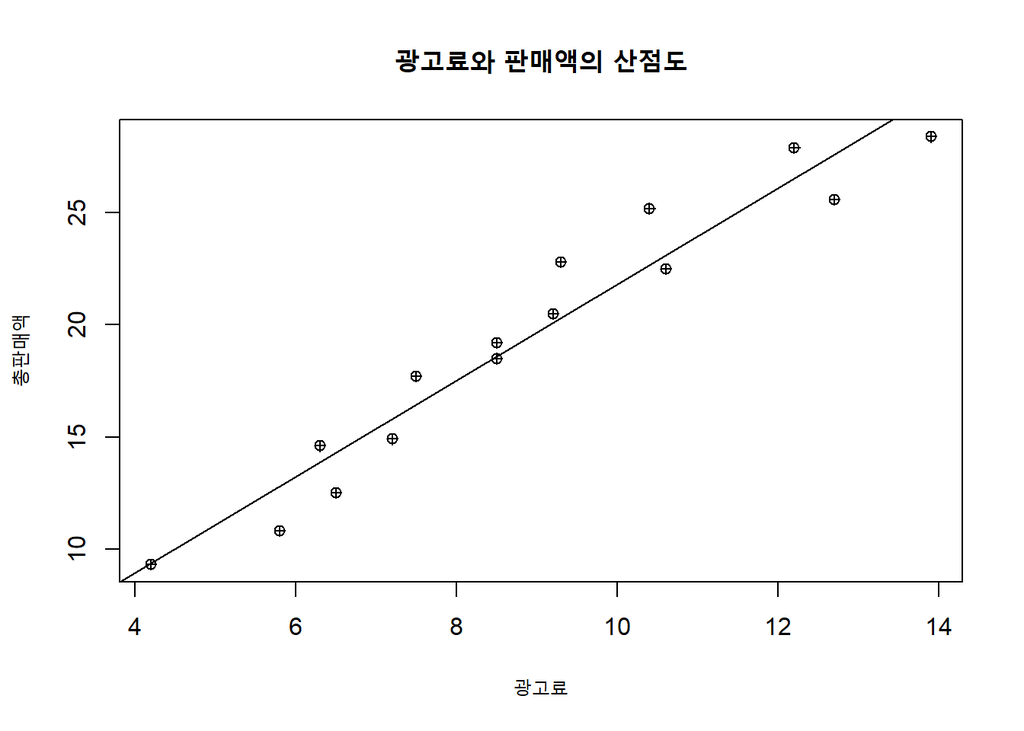

```r
plot(market$X, market$Y, xlab="광고료", ylab="총판매액", pch=10, main="광고료와 판매액의 산점도")
abline(market.lm)
```

**잔차(residual)**  
적합된 회귀직선 $\hat{Y}=b_0+b_1X$에서 $X$대신에 $i$번째 $X$값 $X_i$를 사용하면 $\hat{Y}=b_0+b_1X_i$가 되는데, 여기서 $\hat{Y}_i$는 $X_i$에서의 기대값 $E(Y_i)$의 추정값이다. $X_i$에서 측정된 값 $Y_i$와 추정된 $\hat{Y}_i$와의 차이 $\epsilon_i = Y_i - \hat{Y}_i$를 잔차라고 부르며, 추정된 모형의 적합성 등에 널리 이용된다. 회귀계수 $b_0, b_1$이 최소제곱법에 의한 추정값이면 다음과 같이 흥미로운 성질이 성립된다.

1. 잔차들의 합은 0이다. 즉 $\sum\epsilon_i=0$
2. 잔차제곱의 합, $\sum\epsilon_i^2$은 최소가 된다. 이것은 최소제곱법에 의하여 $b_0$와 $b_1$을 구할 때 요구된 성질이므로 명백하다.
3. 관찰값 $Y_i$의 합과 추정값 $\hat{Y}_i$의 합은 같다. 즉, $\sum Y_i=\sum\hat{Y}_i$이는 $\sum \epsilon_i = \sum Y_i -\sum\hat{Y}_i=0$이므로 명백하다.
4. 잔차들의 $X_i$에 의한 가중값은 0이다. 즉, $\sum X_i\epsilon_i = 0$
5. 잔차들의 $\hat{Y}_i$에 의하 가중값은 0이다. 즉, $\sum \hat{Y}_i\epsilon_i = 0$ 여기서
   $$\begin{matrix}\sum
   \hat{Y}_i\epsilon_i &=& \sum(b_0+b_1X_i)\epsilon_i \\
   &=&b_0\sum\epsilon_i + b_1\sum X_i\epsilon_i \\
   &=&0 \end{matrix}$$
   임을 쉽게 알 수 있다.
6. 점 ($\bar{X}, \bar{Y}$)는 적합된 회귀선상에 있다. 이는 식 $\hat{Y} = \bar{Y} + b_1(X_i-\bar{X})$에서 ($\bar{X}, \bar{Y}$)가 회귀선상에 있음이 명백하다.

```r
# 파일 읽기 및 linear model 값
market = read.table("./data/market-1.txt", header = T)
market.lm = lm(Y~X, data=market)

# 어떤 변수들이 있는지 확인 및 resid, fitted(Y의 추정값) 변수에 저장
names(market.lm)
```

```
##  [1] "coefficients"  "residuals"     "effects"       "rank"
##  [5] "fitted.values" "assign"        "qr"            "df.residual"
##  [9] "xlevels"       "call"          "terms"         "model"
```

```r
resid=market.lm$residuals
fitted=market.lm$fitted.values
# sum(resid) 결과값이 책과는 다르다 하지만 0.00000000 수준으로 0에 가깝기 때문에 0으로 간주하면 동일한 결과로 보면 될것 같다.
sum(resid)
```

```
## [1] -2.359224e-15
```

```r
# sum(fitted)와 sum(market$Y)의 값은 동일
sum(fitted);sum(market$Y)
```

```
## [1] 290.4
```

```
## [1] 290.4
```

```r
# 잔차들의 X에 의한 가중합 = 0에 가깝다
sum(market$X*resid)
```

```
## [1] -1.86795e-14
```

```r
#잔차들의 Y에 의한 가중합 = 0에 가깝다.
sum(fitted*resid)
```

```
## [1] -4.82947e-14
```

## 회귀모형의 정도

**분산분석표에 의한 F-검정**

| 요인 | 자유도 | 제곱합 | 평균제곱 | $F_0$ | $Pr(>F)$ |
| --- | --- | --- | --- | --- | --- |
| 회귀 | 1 | SSR | $MSR = \frac{SSR}{1}$ | $\frac{MSR}{MSE}$ |  |
| 잔차 | n-2 | SSE | $MSE = \frac{SSE}{n-2}$ |  |  |
| 계 | n-1 | SST |  |  |  |

```r
# 파일 읽기 및 linear model 값
market = read.table("./data/market-1.txt", header = T)
market.lm = lm(Y~X, data=market)
anova(market.lm)
```

```
## Analysis of Variance Table
##
## Response: Y
##           Df Sum Sq Mean Sq F value    Pr(>F)
## X          1 485.57  485.57   192.9 3.554e-09 ***
## Residuals 13  32.72    2.52
## ---
## Signif. codes:  0 '***' 0.001 '**' 0.01 '*' 0.05 '.' 0.1 ' ' 1
```

자유도: DF, 제곱합: sum Sq, 평균제곱: mean Sq, $F_0$: F value, $Pr(>F)$: Pr(>F),  
SST = SSR + SSE  
결정계수 $R^2 = 485.57 / ( 485.57 + 32.72) = 0.9368$로 이는 총변동 중 회귀직선에 의하여 설명되는 부분이 93.68%라는 의미로서, 추정된 회귀선의 상관관계 정도가 높다는 것을 알 수 있음.

분산분석결과해석:  
p-값이 $3.554e-09$로 매우 작은 값이므로 귀무가설 $H_0:\beta_1=0$을 기각.  
참고 1: 유의수준 0.05에서 F-기각역

```r
# F-분포 분위함수 : qf(1-알파, 회귀 자유도, 잔차 자유도) ? 기각역 부분...
qf(0.95,1,13)
```

```
## [1] 4.667193
```

192.9 > 4.667193 이기 때문에 귀무가설을 기각함.  
참고 2: p-값 구하기

```r
# P-값 누적 분포 함수 : 오른쪽 95% ~ 100% 범위이기 때문에 1에서 빼줘야 왼쪽 부분의 면적이 됨.
1-pf(192.9, 1, 13)
```

```
## [1] 3.554018e-09
```

분산 분석표에서 $Pr(>F)$값과 동일

**결정계수(coefficient of determination)**
총변동을 설명하는 데 있어서 회귀선에 의하여 설명되는 변동이 기여하는 비율을 의미하므로 *회귀선의 기여율*이라고 부르기도함.
$$R^2=\frac{SSR}{SST} = 1 -
\frac{SSE}{SST} \\
SSE = \sum (Y_i - \hat{Y}_i)^2, SSR = \sum (\hat{Y}_i - \bar{Y})^2, \\
SST = SSE + SSR = \sum (Y_i - \bar{Y})^2$$
: 총 변동중에서 회귀선에 의하여 설명되는 비율이며 $R^2$의 범위는 $0 \le R^2 \le 1$임.
$X$와 $Y$사이에 높은 상관관계가 있을수록 $R^2$의 값은 1에 가까워짐. 즉, $R^2$의 값이 0에 가까운 값을 가지는 회귀선은 쓸모가 없는 회귀선으로 유용성이 낮다.

**추정값의 표준오차**  
분산분석표에서 잔차평균제곱 $MSE$는 오차분산 $\sigma^2$의 불편추정량이 됨. 따라서 $MSE$의 제곱근을 추정값의 표준오차(standard error of estimate)라고 부른다.

```r
# 파일 읽기 및 linear model 값
market = read.table("./data/market-1.txt", header = T)
market.lm = lm(Y~X, data=market)
summary(market.lm)
```

```
##
## Call:
## lm(formula = Y ~ X, data = market)
##
## Residuals:
##      Min       1Q   Median       3Q      Max
## -2.02908 -1.35349 -0.05685  0.98903  2.51517
##
## Coefficients:
##             Estimate Std. Error t value Pr(>|t|)
## (Intercept)   0.3282     1.4302   0.229    0.822
## X             2.1497     0.1548  13.889 3.55e-09 ***
## ---
## Signif. codes:  0 '***' 0.001 '**' 0.01 '*' 0.05 '.' 0.1 ' ' 1
##
## Residual standard error: 1.587 on 13 degrees of freedom
## Multiple R-squared:  0.9369, Adjusted R-squared:  0.932
## F-statistic: 192.9 on 1 and 13 DF,  p-value: 3.554e-09
```

Residual standard error: 1.587  
$MSE = SSE / ( n-2) = 2.52$(anova 결과에서 residuals의 mean Sq)  
$S_{Y\cdot X}=\sqrt{MSE}=\sqrt{2.52}=1.587$

**상관계수와 결정계수 관계**  
*상관계수*: 상관계수는 두 연속인 변수간의 선형관계가 어느정도인가를 재는 측도 $r=\frac{S_{XY}}{\sqrt{S_{XX} S_{YY}}}$  
단순회귀분석에서는 상관계수 r을 다음과 같이 구할 수 있다. $r=\pm \sqrt{R^2}$ 즉, 상관계수는 결정계수 $R^2$의 제곱근이며, 만약 추정된 회귀서의 기울기 $b_1$이 양이면 $r=\sqrt{R^2}$으로 양의 상관계수를 갖고, $b_1$이 음이면 $r=-\sqrt{R^2}$으로 음의 상관관계를 가짐.

## $\beta_1$의 신뢰구간

**R 결과에서 $\beta_1, \beta_0$ 신뢰구간 구하기**

```r
market.lm = lm(Y~X,data = market)
market.anova = anova(market.lm)
(market.summary=summary(market.lm))
```

```
##
## Call:
## lm(formula = Y ~ X, data = market)
##
## Residuals:
##      Min       1Q   Median       3Q      Max
## -2.02908 -1.35349 -0.05685  0.98903  2.51517
##
## Coefficients:
##             Estimate Std. Error t value Pr(>|t|)
## (Intercept)   0.3282     1.4302   0.229    0.822
## X             2.1497     0.1548  13.889 3.55e-09 ***
## ---
## Signif. codes:  0 '***' 0.001 '**' 0.01 '*' 0.05 '.' 0.1 ' ' 1
##
## Residual standard error: 1.587 on 13 degrees of freedom
## Multiple R-squared:  0.9369, Adjusted R-squared:  0.932
## F-statistic: 192.9 on 1 and 13 DF,  p-value: 3.554e-09
```

```r
(q.val = qt(0.975, 13))
```

```
## [1] 2.160369
```

```r
c(2.1497-q.val*0.1548, 2.1497+q.val*0.1548)
```

```
## [1] 1.815275 2.484125
```

```r
# 2.1497 : X의 추정값
X_hat = market.summary$coefficients[2,1]
# 0.1548
X_std.error = market.summary$coefficients[2,2]

# 다시 수식을 이용해서 계산해보면
alpha = 0.05; n = length(market$Y)
(q.val=qt(1-alpha/2, 13))
```

```
## [1] 2.160369
```

```r
c(X_hat-q.val*X_std.error, X_hat+q.val*X_std.error)
```

```
## [1] 1.815301 2.484046
```

*$\beta_0$의 95% 신뢰구간*

```r
# q.val값은 동일하여 새로 구하지 않는다.
# Intercept_hat : 절편의 추정값
I_hat = market.summary$coefficients[1,1]
# 절편의 잔차값
I_std.error = market.summary$coefficients[1,2]
c(I_hat-q.val*I_std.error, I_hat+q.val*I_std.error)
```

```
## [1] -2.761546  3.417987
```

### 추정값에 대한 신뢰구간 내용 정리는 나중에

*X의 주어진 값에서 신뢰대 그리기*

```r
pred.frame = data.frame(X=c(3.5,14.5))
pc = predict(market.lm, int="c", newdata=pred.frame); head(pc,3)
```

```
##         fit       lwr       upr
## 1  7.852079  5.855247  9.848911
## 2 31.498492 29.413283 33.583701
```

```r
pp = predict(market.lm, interval = "p", newdata=pred.frame); head(pp,3)
```

```
##         fit       lwr      upr
## 1  7.852079  3.885278 11.81888
## 2 31.498492 27.486476 35.51051
```

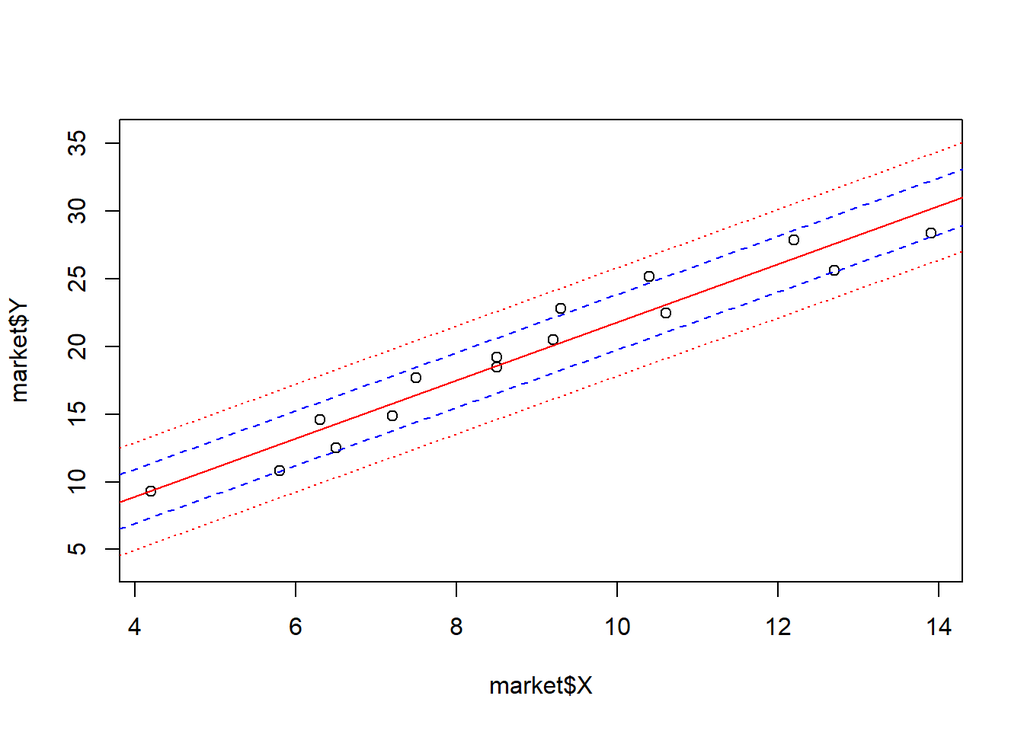

```r
plot(market$X, market$Y, ylim=range(market$Y, pp))
# matrix line, lty : line type 1 직선, 2 점선, 3 더 작은 점선
matlines(pred.frame$X, pc, lty = c(1,2,2), col="BLUE")
matlines(pred.frame$X, pp, lty = c(1,3,3), col="RED")
```

*$\beta_1$검정*

```r
# t-value : X의 Estimate / Std.Error
market.summary$coefficients[2,1]/market.summary$coefficients[2,2]
```

```
## [1] 13.88896
```

```r
# X의 t-value
(t_0=market.summary$coefficients[2,3])
```

```
## [1] 13.88896
```

```r
# 유의수준 0.05 기각역
alpha = 0.05; n = length(market$Y)
(q.val=qt(1-alpha/2, 13))
```

```
## [1] 2.160369
```

```r
# 유의확률 값 : 직접 구하는 방법
2*(1-pt(t_0, 13))
```

```
## [1] 3.553647e-09
```

```r
# 유의확률 값 : summary에서 가져오는 방법
(p.value=market.summary$coefficients[2,4])
```

```
## [1] 3.553647e-09
```

## 가중회귀

**가중최소제곱법**  
오차항마다 분산이 다른 경우 가중최소제곱법을 사용하여 회귀분석하는 것을 가중회귀

```r
x = c(1,2,3,4,5)
y = c(2,3,5,8,7)
w = 1/x
w.lm  = lm(y~x, weights=w)
(w.lm.summary = summary(w.lm))
```

```
##
## Call:
## lm(formula = y ~ x, weights = w)
##
## Weighted Residuals:
##          1          2          3          4          5
##  8.108e-02 -3.249e-01 -1.076e-16  7.297e-01 -4.835e-01
##
## Coefficients:
##             Estimate Std. Error t value Pr(>|t|)
## (Intercept)   0.3784     0.6891   0.549   0.6212
## x             1.5405     0.2688   5.730   0.0106 *
## ---
## Signif. codes:  0 '***' 0.001 '**' 0.01 '*' 0.05 '.' 0.1 ' ' 1
##
## Residual standard error: 0.5411 on 3 degrees of freedom
## Multiple R-squared:  0.9163, Adjusted R-squared:  0.8884
## F-statistic: 32.84 on 1 and 3 DF,  p-value: 0.01055
```

## 분석사례

```r
# 자료 읽기
super = read.table("./data/supermarket.txt", header = T)
head(super, 3)
```

```
##   price time
## 1   6.4  1.7
## 2  16.1  2.7
## 3  42.1  4.9
```

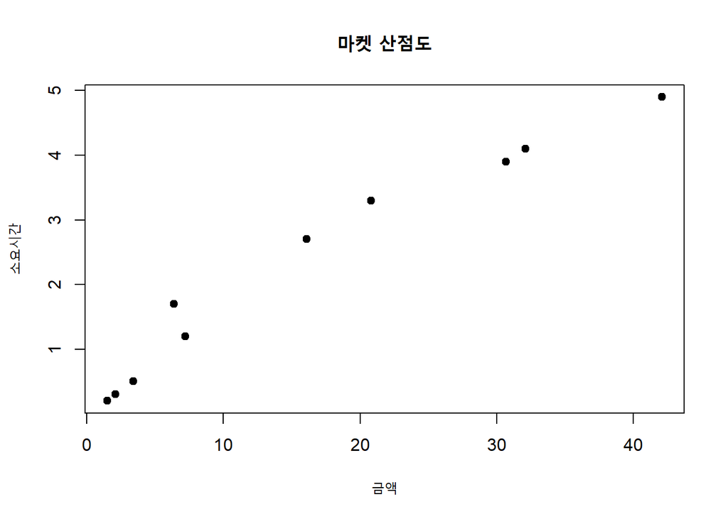

```r
# 객체의 변수를 객체없이 접근하기 위해서 attach
attach(super)
# 산점도를 그린다.
plot(price,time,pch=19, xlab="금액", ylab="소요시간", main="마켓 산점도")
```

```r
# 회귀모형 적합
super.lm = lm(time~price, data=super)
(super.summary = summary(super.lm))
```

```
##
## Call:
## lm(formula = time ~ price, data = super)
##
## Residuals:
##      Min       1Q   Median       3Q      Max
## -0.37928 -0.32771 -0.04431  0.32231  0.56126
##
## Coefficients:
##             Estimate Std. Error t value Pr(>|t|)
## (Intercept) 0.396460   0.191488    2.07   0.0722 .
## price       0.115982   0.008979   12.92 1.22e-06 ***
## ---
## Signif. codes:  0 '***' 0.001 '**' 0.01 '*' 0.05 '.' 0.1 ' ' 1
##
## Residual standard error: 0.3925 on 8 degrees of freedom
## Multiple R-squared:  0.9542, Adjusted R-squared:  0.9485
## F-statistic: 166.9 on 1 and 8 DF,  p-value: 1.221e-06
```

*분산분석표*

```r
(super.anova=anova(super.lm))
```

```
## Analysis of Variance Table
##
## Response: time
##           Df  Sum Sq Mean Sq F value    Pr(>F)
## price      1 25.7036 25.7036  166.85 1.221e-06 ***
## Residuals  8  1.2324  0.1541
## ---
## Signif. codes:  0 '***' 0.001 '**' 0.01 '*' 0.05 '.' 0.1 ' ' 1
```

분산분석표에서 보면 검전통계량 $F_0=166.85$이고, 이에대한 p-값=1.221e-06으로서 적합된 회귀직선이 유의하다는 것을 알수있다.  
*잔차 및 추정값보기*

```r
names(super.lm)
```

```
##  [1] "coefficients"  "residuals"     "effects"       "rank"
##  [5] "fitted.values" "assign"        "qr"            "df.residual"
##  [9] "xlevels"       "call"          "terms"         "model"
```

```r
cbind(super, super.lm$resid, super.lm$fitted)
```

```
##    price time super.lm$resid super.lm$fitted
## 1    6.4  1.7     0.56125840        1.138742
## 2   16.1  2.7     0.43623742        2.263763
## 3   42.1  4.9    -0.37928275        5.279283
## 4    2.1  0.3    -0.34002095        0.640021
## 5   30.7  3.9    -0.05709314        3.957093
## 6   32.1  4.1    -0.01946730        4.119467
## 7    7.2  1.2    -0.03152683        1.231527
## 8    3.4  0.5    -0.29079696        0.790797
## 9   20.8  3.3     0.49112416        2.808876
## 10   1.5  0.2    -0.37043203        0.570432
```

*잔차 그림 그리기*

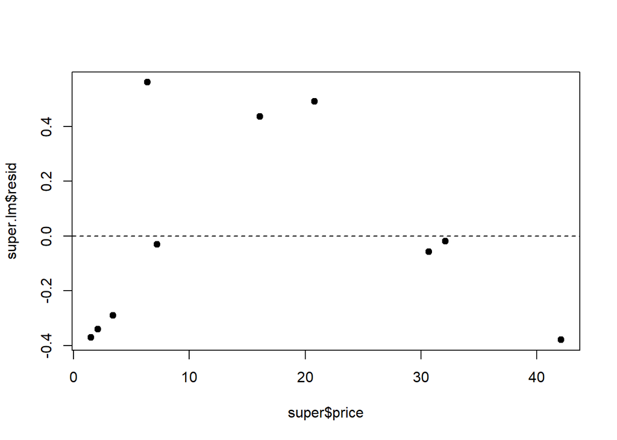

```r
plot(super$price, super.lm$resid, pch=19)
abline(h=0, lty=2)
```

*추정값의 신뢰대 그리기*

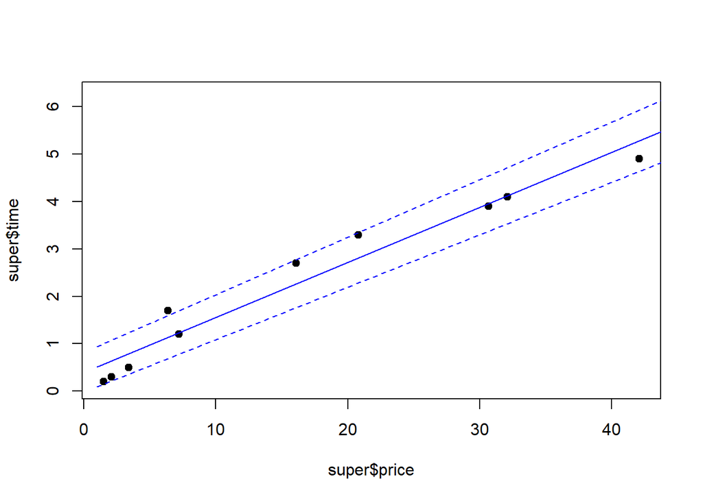

```r
p.x = data.frame(price=c(1,45))
pc = predict(super.lm, int="c", newdata = p.x)
plot(super$price, super$time, ylim=range(super$time, pc), pch=19)
matlines(p.x$price, pc, lty=c(1,2,2), col="BLUE")
```

### 회귀모형 정리

```r
# market-1.txt 파일을 읽어서
# 파일 읽기 및 linear model 값
market = read.table("./data/market-1.txt", header = T)
market.lm = lm(Y~X, data=market)
summary(market.lm)
```

```
##
## Call:
## lm(formula = Y ~ X, data = market)
##
## Residuals:
##      Min       1Q   Median       3Q      Max
## -2.02908 -1.35349 -0.05685  0.98903  2.51517
##
## Coefficients:
##             Estimate Std. Error t value Pr(>|t|)
## (Intercept)   0.3282     1.4302   0.229    0.822
## X             2.1497     0.1548  13.889 3.55e-09 ***
## ---
## Signif. codes:  0 '***' 0.001 '**' 0.01 '*' 0.05 '.' 0.1 ' ' 1
##
## Residual standard error: 1.587 on 13 degrees of freedom
## Multiple R-squared:  0.9369, Adjusted R-squared:  0.932
## F-statistic: 192.9 on 1 and 13 DF,  p-value: 3.554e-09
```